# Exploratory Data Analysis

## Cardio Dataset

### Marcos Barragán Corredera

### 30/10/2020

In this practice I am going to produce an exploratory data analysis (EDA) of cardiac diseases dataset, trying to find NA values, duplicated entries, and relations between variables and target: Cardio Disease.

This dataset contains 70000 entries divided in 13 variables.

```python
import pandas as pd
import numpy as np
import matplotlib.pyplot as plt
import seaborn as sns
```

## Familiarizing with the data

First of all, we have to load the csv dataset.

```python
cardio = pd.read_csv("cardio_train.csv", delimiter = ';')
```

If we check what kind of data we are trating, we will see the variables I have named and defined at the beggining of the work.

As I said, these dataset contains 70k entries divided in 13 columns. These features are: These features are:

```python
cardio.head(6)
```

|  | id | age | gender | height | weight | ap_hi | ap_lo | cholesterol | gluc | smoke | alco | active | cardio |
| --- | --- | --- | --- | --- | --- | --- | --- | --- | --- | --- | --- | --- | --- |
| 0 | 0 | 18393 | 2 | 168 | 62.0 | 110 | 80 | 1 | 1 | 0 | 0 | 1 | 0 |
| 1 | 1 | 20228 | 1 | 156 | 85.0 | 140 | 90 | 3 | 1 | 0 | 0 | 1 | 1 |
| 2 | 2 | 18857 | 1 | 165 | 64.0 | 130 | 70 | 3 | 1 | 0 | 0 | 0 | 1 |
| 3 | 3 | 17623 | 2 | 169 | 82.0 | 150 | 100 | 1 | 1 | 0 | 0 | 1 | 1 |
| 4 | 4 | 17474 | 1 | 156 | 56.0 | 100 | 60 | 1 | 1 | 0 | 0 | 0 | 0 |
| 5 | 8 | 21914 | 1 | 151 | 67.0 | 120 | 80 | 2 | 2 | 0 | 0 | 0 | 0 |

We see that there is a variable called `id`, which corresponds to the index of the entries. This is completly unusefull, because Python puts an index itself, so we don´t need two entries for indexes.

Because of this, I will drop `id`column.

```python
cardio = cardio.drop('id', axis=1)
```

Secondly, we have to transform some variables:

```python
cardio['age'] = cardio.age.map(lambda x: round(x/365))

cardio['IMC'] = cardio.weight/(cardio.height/100)**2

cardio['IMC'] = cardio.IMC.map(lambda x: 'Underweight' if (x < 18.5) else 'Normal' if (18.5 < x < 25) else
                       'Overweight' if (25 <= x <30) else 'Obese')
```

```python
def BP(datos):

    if (datos['ap_hi'] <= 90) | (datos['ap_lo'] <= 60):

        return 'Low Blood Pressure'

    if (datos['ap_hi'] <= 120) and (datos['ap_lo'] <= 80):

        return 'Normal'

    if (datos['ap_hi'] >= 120 and datos['ap_hi'] < 140) | (datos['ap_lo']>80 and datos['ap_lo'] < 90):

        return 'Elevated'

    if (datos['ap_hi'] >= 140 and datos['ap_hi'] < 160) | (datos['ap_lo'] >= 90 and datos['ap_lo'] < 100):

        return 'High Pressure Level 1'

    if (datos['ap_hi'] >= 160 and datos['ap_hi'] < 180) | (datos['ap_lo'] >= 100 and datos['ap_lo'] < 110):

        return 'High Pressure Level 2'

    if (datos['ap_hi'] >= 180) | (datos['ap_lo'] >= 110):

        return 'High Pressure Level 3'

cardio['BP'] = cardio.apply(BP, axis=1)
```

If we check the cardio dataset now, we notice that it has a better form:

```python
cardio.head(7)
```

|  | age | gender | height | weight | ap_hi | ap_lo | cholesterol | gluc | smoke | alco | active | cardio | IMC | BP |
| --- | --- | --- | --- | --- | --- | --- | --- | --- | --- | --- | --- | --- | --- | --- |
| 0 | 50 | 2 | 168 | 62.0 | 110 | 80 | 1 | 1 | 0 | 0 | 1 | 0 | Normal | Normal |
| 1 | 55 | 1 | 156 | 85.0 | 140 | 90 | 3 | 1 | 0 | 0 | 1 | 1 | Obese | High Pressure Level 1 |
| 2 | 52 | 1 | 165 | 64.0 | 130 | 70 | 3 | 1 | 0 | 0 | 0 | 1 | Normal | Elevated |
| 3 | 48 | 2 | 169 | 82.0 | 150 | 100 | 1 | 1 | 0 | 0 | 1 | 1 | Overweight | High Pressure Level 1 |
| 4 | 48 | 1 | 156 | 56.0 | 100 | 60 | 1 | 1 | 0 | 0 | 0 | 0 | Normal | Low Blood Pressure |
| 5 | 60 | 1 | 151 | 67.0 | 120 | 80 | 2 | 2 | 0 | 0 | 0 | 0 | Overweight | Normal |
| 6 | 61 | 1 | 157 | 93.0 | 130 | 80 | 3 | 1 | 0 | 0 | 1 | 0 | Obese | Elevated |

If I calculate the main statistical values of the different entries, we will see, for each column:

- Number of values for each variable.
- Mean
- Standard Deviation
- Min values
- First quantile
- Median (Second quantile)
- Third quantile
- Max values

```python
cardio.describe()
```

|  | age | gender | height | weight | ap_hi | ap_lo | cholesterol | gluc | smoke | alco | active | cardio |
| --- | --- | --- | --- | --- | --- | --- | --- | --- | --- | --- | --- | --- |
| count | 70000.000000 | 70000.000000 | 70000.000000 | 70000.000000 | 70000.000000 | 70000.000000 | 70000.000000 | 70000.000000 | 70000.000000 | 70000.000000 | 70000.000000 | 70000.000000 |
| mean | 53.338686 | 1.349571 | 164.359229 | 74.205690 | 128.817286 | 96.630414 | 1.366871 | 1.226457 | 0.088129 | 0.053771 | 0.803729 | 0.499700 |
| std | 6.765294 | 0.476838 | 8.210126 | 14.395757 | 154.011419 | 188.472530 | 0.680250 | 0.572270 | 0.283484 | 0.225568 | 0.397179 | 0.500003 |
| min | 30.000000 | 1.000000 | 55.000000 | 10.000000 | -150.000000 | -70.000000 | 1.000000 | 1.000000 | 0.000000 | 0.000000 | 0.000000 | 0.000000 |
| 25% | 48.000000 | 1.000000 | 159.000000 | 65.000000 | 120.000000 | 80.000000 | 1.000000 | 1.000000 | 0.000000 | 0.000000 | 1.000000 | 0.000000 |
| 50% | 54.000000 | 1.000000 | 165.000000 | 72.000000 | 120.000000 | 80.000000 | 1.000000 | 1.000000 | 0.000000 | 0.000000 | 1.000000 | 0.000000 |
| 75% | 58.000000 | 2.000000 | 170.000000 | 82.000000 | 140.000000 | 90.000000 | 2.000000 | 1.000000 | 0.000000 | 0.000000 | 1.000000 | 1.000000 |
| max | 65.000000 | 2.000000 | 250.000000 | 200.000000 | 16020.000000 | 11000.000000 | 3.000000 | 3.000000 | 1.000000 | 1.000000 | 1.000000 | 1.000000 |

We can implement a scatter plot between non-binary values to check the outliers and error values:

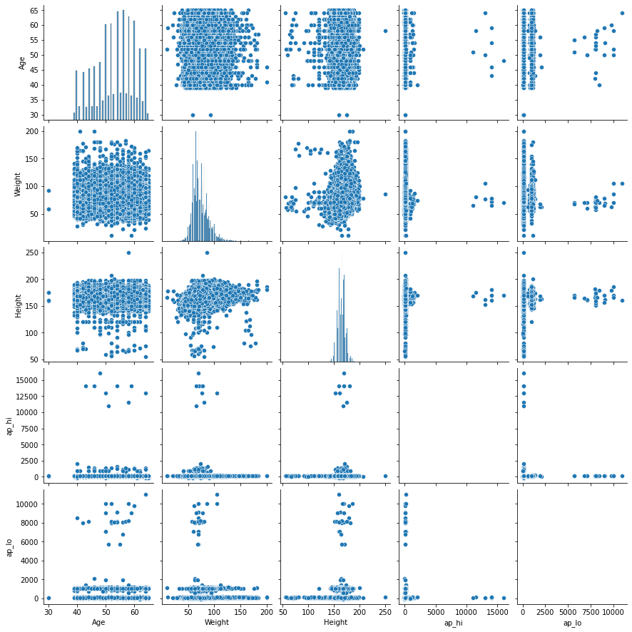

```python
#Creating a new dataframe which only contains non-binary variables of the dataset.

pp = pd.DataFrame({"Age": cardio.age,
                   "Weight": cardio.weight,
                   "Height": cardio.height,
                   "ap_hi": cardio.ap_hi,
                   "ap_lo": cardio.ap_lo,
                   "IMC":cardio.IMC,
                   "BP": cardio.BP})

sns.pairplot(pp);
```

As we can see, there are some mistakes in the features. We can notice it in:

- `height` have a minimum value of 55 cm and a maximum value of 250 cm, which are exorbitant values for this variable.
- `weight` have a minimum value of 10 kg, which is ridiculous, and a maximum of 200 kg (which is strange but not impossible).
- `ap_lo` and `ap_hi` have negative minimum values, which is impossible, but also maximum values bigger than 10000, which must be a mistake. If we look at the pairplot, we will see many outliers that we should remove.

Then, in order to get a better EDA fro the data, I should drop out this values. Particularly, I will delete:

- Height values over 200 cm and under 140 cm.
- Weight values under 40 kg.
- Systolic BP under 70 mmHg and over 230 mmHg
- Diastolic BP under 40 mmHg and over 170 mmHg
- Of course rows where `ap_hi` - `ap_lo` < 0 must be thrown away too.

Checking if we have any null entry in columns or duplicated values in it:

```python
cardio.isnull().sum()
```

```
age            0
gender         0
height         0
weight         0
ap_hi          0
ap_lo          0
cholesterol    0
gluc           0
smoke          0
alco           0
active         0
cardio         0
IMC            0
BP             0
dtype: int64
```

Dataset doesn´t have any null value, so I have one less thing to concern about.

It has duplicated values, as we can see below:

```python
duplicated = cardio[cardio.duplicated(keep=False)]

duplicated.sort_values(['age', 'height', 'weight'])  #Sorting it to clarificate it.
```

|  | age | gender | height | weight | ap_hi | ap_lo | cholesterol | gluc | smoke | alco | active | cardio | IMC | BP |
| --- | --- | --- | --- | --- | --- | --- | --- | --- | --- | --- | --- | --- | --- | --- |
| 5984 | 39 | 2 | 165 | 65.0 | 120 | 80 | 1 | 1 | 0 | 0 | 0 | 0 | Normal | Normal |
| 15114 | 39 | 2 | 165 | 65.0 | 120 | 80 | 1 | 1 | 0 | 0 | 0 | 0 | Normal | Normal |
| 37423 | 39 | 1 | 170 | 72.0 | 120 | 80 | 1 | 1 | 0 | 0 | 1 | 0 | Normal | Normal |
| 66714 | 39 | 1 | 170 | 72.0 | 120 | 80 | 1 | 1 | 0 | 0 | 1 | 0 | Normal | Normal |
| 4590 | 40 | 1 | 151 | 58.0 | 110 | 70 | 1 | 1 | 0 | 0 | 1 | 0 | Overweight | Normal |
| ... | ... | ... | ... | ... | ... | ... | ... | ... | ... | ... | ... | ... | ... | ... |
| 44102 | 65 | 1 | 163 | 63.0 | 120 | 80 | 1 | 1 | 0 | 0 | 0 | 1 | Normal | Normal |
| 48386 | 65 | 1 | 168 | 64.0 | 120 | 80 | 1 | 1 | 0 | 0 | 0 | 1 | Normal | Normal |
| 69356 | 65 | 1 | 168 | 64.0 | 120 | 80 | 1 | 1 | 0 | 0 | 0 | 1 | Normal | Normal |
| 59745 | 65 | 2 | 174 | 70.0 | 120 | 80 | 1 | 1 | 0 | 0 | 1 | 1 | Normal | Normal |
| 67250 | 65 | 2 | 174 | 70.0 | 120 | 80 | 1 | 1 | 0 | 0 | 1 | 1 | Normal | Normal |

6414 rows × 14 columns

Deleting all those values I mentioned before and saving them into a new dataframe called `cardio2`:

```python
cardio2 = cardio.copy()
```

```python
cardio2.drop(cardio2[(cardio2.ap_lo - cardio2.ap_hi > 0)].index, inplace = True)
cardio2.drop(cardio2[(cardio2.ap_hi >= 230)|(cardio2.ap_lo <= 40)].index, inplace = True)
cardio2.drop(cardio2[(cardio2.ap_hi <= 70)|(cardio2.ap_lo >= 170)].index, inplace = True)
cardio2.drop(cardio2[(cardio2.height > 200)|(cardio2.height <= 140)]. index, inplace = True)
cardio2.drop(cardio2[(cardio2.weight < 40)]. index, inplace = True)
cardio2.drop_duplicates(inplace=True)
cardio2
```

|  | age | gender | height | weight | ap_hi | ap_lo | cholesterol | gluc | smoke | alco | active | cardio | IMC | BP |
| --- | --- | --- | --- | --- | --- | --- | --- | --- | --- | --- | --- | --- | --- | --- |
| 0 | 50 | 2 | 168 | 62.0 | 110 | 80 | 1 | 1 | 0 | 0 | 1 | 0 | Normal | Normal |
| 1 | 55 | 1 | 156 | 85.0 | 140 | 90 | 3 | 1 | 0 | 0 | 1 | 1 | Obese | High Pressure Level 1 |
| 2 | 52 | 1 | 165 | 64.0 | 130 | 70 | 3 | 1 | 0 | 0 | 0 | 1 | Normal | Elevated |
| 3 | 48 | 2 | 169 | 82.0 | 150 | 100 | 1 | 1 | 0 | 0 | 1 | 1 | Overweight | High Pressure Level 1 |
| 4 | 48 | 1 | 156 | 56.0 | 100 | 60 | 1 | 1 | 0 | 0 | 0 | 0 | Normal | Low Blood Pressure |
| ... | ... | ... | ... | ... | ... | ... | ... | ... | ... | ... | ... | ... | ... | ... |
| 69995 | 53 | 2 | 168 | 76.0 | 120 | 80 | 1 | 1 | 1 | 0 | 1 | 0 | Overweight | Normal |
| 69996 | 62 | 1 | 158 | 126.0 | 140 | 90 | 2 | 2 | 0 | 0 | 1 | 1 | Obese | High Pressure Level 1 |
| 69997 | 52 | 2 | 183 | 105.0 | 180 | 90 | 3 | 1 | 0 | 1 | 0 | 1 | Obese | High Pressure Level 1 |
| 69998 | 61 | 1 | 163 | 72.0 | 135 | 80 | 1 | 2 | 0 | 0 | 0 | 1 | Overweight | Elevated |
| 69999 | 56 | 1 | 170 | 72.0 | 120 | 80 | 2 | 1 | 0 | 0 | 1 | 0 | Normal | Normal |

64592 rows × 14 columns

If we make again the pair plot for cardio2:

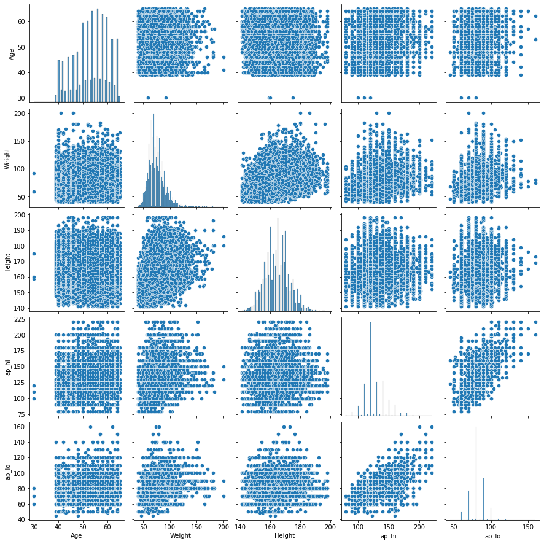

```python
pp2 = pd.DataFrame({"Age": cardio2.age,
                   "Weight": cardio2.weight,
                   "Height": cardio2.height,
                   "ap_hi": cardio2.ap_hi,
                   "ap_lo": cardio2.ap_lo,
                   "IMC":cardio2.IMC,
                   "BP": cardio2.BP})

sns.pairplot(pp2);
```

We check that now, `cardio 2` data have better distributions, and ouliers and problematic values have decreased considerely (for example, for `ap_lo` and `ap_hi` values).

## EDA analysis of the corrected dataset

Once I have transformed and improved the cardio dataset, I will try to get the relations between variables with each other and with target column `cardio`.

Because of many variables of this dataset are binary or discrete variables, it is not really usefull to trace histograms or scatter plots of them. In order to achieve the best results, I will relate them with the target values using crosstabs, count plots or boxplots involving those binary variables. That is the reason why there will appear so many plotsin this study.

### a) Age as a factor of cardiac Diseaseas

First, I would like to have a look on the ages distribution for cardio diseases.

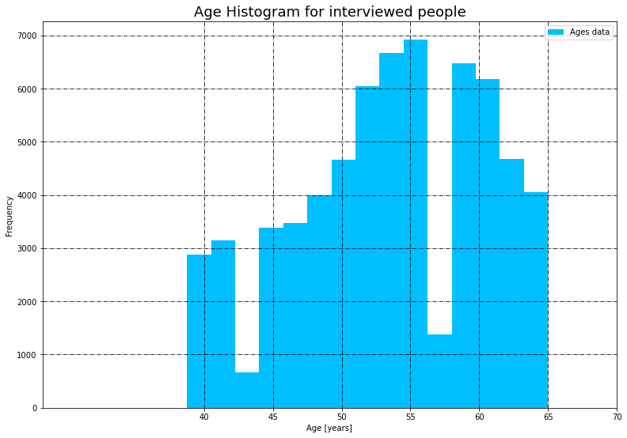

```python
figura, ax1 = plt.subplots(1, figsize = (13, 9))

ax1.hist(cardio2.age, color = 'deepskyblue', bins = 20, label = 'Ages data')
ax1.set_xlabel('Age [years]')
ax1.set_ylabel('Frequency')
ax1.set_title('Age Histogram for interviewed people', size = 18)
ax1.set_xticks([40, 45, 50, 55, 60, 65, 70])
ax1.grid(ls='-.', color = 'black')
ax1.legend();
```

Considering `age` distribution for both `gender`, we notice that males interviewed tend to be younger than females in the dataset:

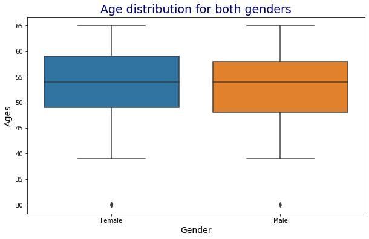

```python
figure, ax1 = plt.subplots(1)
figure.set_size_inches(10,6)

sns.boxplot(cardio2.gender, cardio2.age)
ax1.set_ylabel('Ages', size = 14)
ax1.set_xlabel('Gender', size = 14)
plt.xticks(np.arange(2), ['Female', 'Male'])
ax1.set_title('Age distribution for both genders', size=19, color='Navy');
```

Most of the people interviewed had ages between 50 and 60 years. Dataset doesn´t contain data for people over 65 years, and only few cases were under 39 years.

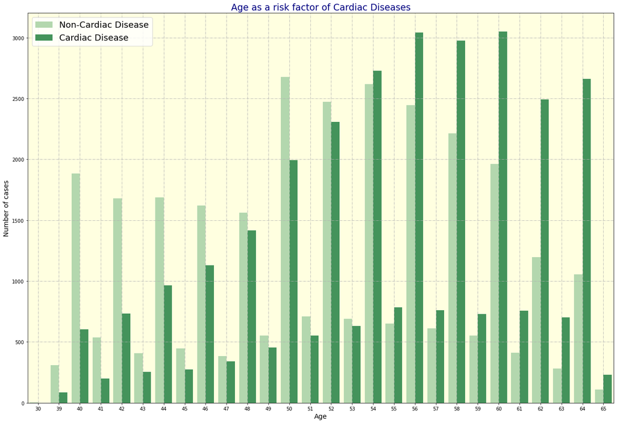

```python
figure, ax1 = plt.subplots(1)
figure.set_size_inches(22,15)
sns.countplot(ax = ax1, x=cardio2.age, hue=cardio2.cardio, palette='Greens')
ax1.grid(ls = '-.')
ax1.set_ylabel('Number of cases', size = 14)
ax1.set_xlabel('Age', size = 14)
ax1.legend(['Non-Cardiac Disease', 'Cardiac Disease'], fontsize = 18, loc = 'upper left')
ax1.set_title('Age as a risk factor of Cardiac Diseases', size=19, color='Navy')
ax1.patch.set_facecolor('lightyellow');
```

In this plot we can see that `age` becomes a risk factor for having cardiac diseases.

### b) Gender as a factor of Cardiac Diseases

If we count the number of people in the dataset grouped by gender, we will see that there were many more females than males asked for the study:

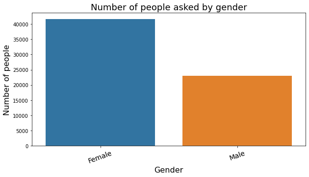

```python
figura, ax1 = plt.subplots(1, figsize = (10, 5))

sns.countplot(cardio2.gender)
plt.xlabel('Gender', size = 16)
plt.ylabel('Number of people', size =16)
plt.title('Number of people asked by gender', size = 18)
plt.xticks(np.arange(2), ['Female', 'Male'], rotation = 20, size = 14);
```

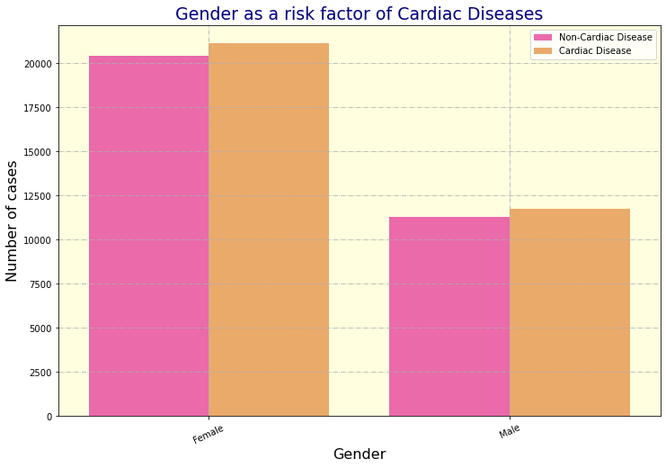

```python
figure, ax1 = plt.subplots(1)
figure.set_size_inches(12,8)

sns.countplot(ax = ax1, x=cardio2.gender, hue=cardio2.cardio, palette='spring')
ax1.grid(ls = '-.')
ax1.legend(['Non-Cardiac Disease', 'Cardiac Disease'])
ax1.set_title('Gender as a risk factor of Cardiac Diseases', size=19, color='Navy')
ax1.set_xlabel('Gender', size = 16)
ax1.set_ylabel('Number of cases', size = 16)
plt.xticks(np.arange(2), ['Female', 'Male'], rotation = 25)
ax1.patch.set_facecolor('lightyellow');
```

We see that there are no significant clues to consider gender as a risk factor. It is clear that there are many more women than men that have cardiac diseases, but this is not abnormal if we have a look to the distribution of asked people's gender. If dataset had the same number of cases for both women and men, this plot would have appeared very different.

### c) Body Mass Index as a factor for CVD

Now it is time to check whether body mass index has relevant information for cardiac diseases.

The distribution of BMI for each gender is clear: there are many more females with higher BMI than males (this could be related to the big differences between number of females and males in the dataset).

We can also see that most of the people in the set is overweighted, and there is so little amount of people underweighted.

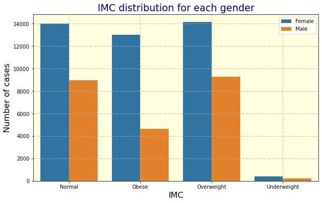

```python
figure, ax1 = plt.subplots(1)
figure.set_size_inches(10,6)

sns.countplot(cardio2.IMC, hue = cardio2.gender)
ax1.grid(ls = '-.')
ax1.legend(['Female', 'Male'])
ax1.set_title('IMC distribution for each gender', size=19, color='Navy')
ax1.set_xlabel('IMC', size = 16)
ax1.set_ylabel('Number of cases', size = 16)
ax1.patch.set_facecolor('lightyellow');
```

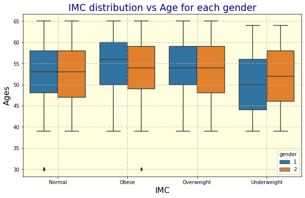

```python
figure, ax1 = plt.subplots(1)
figure.set_size_inches(10,6)

sns.boxplot(cardio2.IMC, cardio2.age, hue = cardio2.gender)
ax1.grid(ls = '-.')
ax1.set_title('IMC distribution vs Age for each gender', size=19, color='Navy')
ax1.set_xlabel('IMC', size = 16)
ax1.set_ylabel('Ages', size = 16)
ax1.patch.set_facecolor('lightyellow');
```

We see that obese and overweight people tend to be younger in the case of males than in the case of females. It is specially significant for obese people.

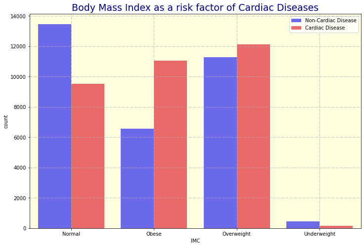

```python
figure, ax1 = plt.subplots(1)
figure.set_size_inches(12,8)

sns.countplot(ax = ax1, x=cardio2.IMC, hue=cardio2.cardio, palette='seismic')
ax1.grid(ls = '-.')
ax1.legend(['Non-Cardiac Disease', 'Cardiac Disease'])
ax1.set_title('Body Mass Index as a risk factor of Cardiac Diseases', size=19, color='Navy')
ax1.patch.set_facecolor('lightyellow');
```

It is clear that being obese will lead you to have CV diseases. Being overweight is also a risk factor for having that disease. We see that the higher your BMI, the higher the risk for having CV problems.

### d) Cholesterol Level as a factor for CVD.

If we study now the behaviour of `cholesterol` level vs `cardiac` disease target, we will test that the higher cholesterol level, the higher probability for getting a CV disease.

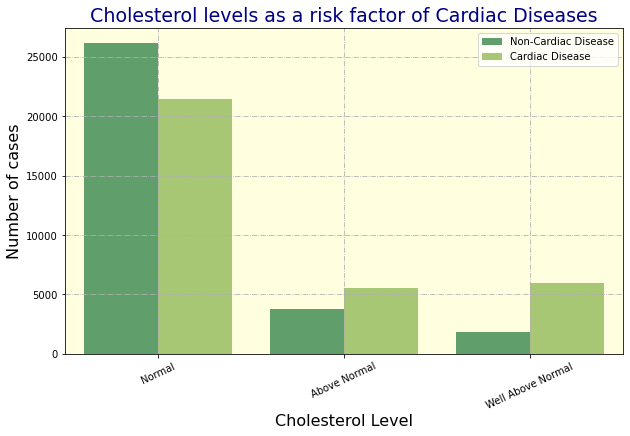

```python
figure, ax1 = plt.subplots(1)
figure.set_size_inches(10,6)

sns.countplot(ax = ax1, x=cardio2.cholesterol, hue=cardio2.cardio, palette='summer')
ax1.grid(ls = '-.')
ax1.set_xlabel('Cholesterol Level', size = 16)
ax1.set_ylabel('Number of cases', size = 16)
plt.xticks(np.arange(3), ['Normal', 'Above Normal', 'Well Above Normal'], rotation = 25)
ax1.legend(['Non-Cardiac Disease', 'Cardiac Disease'])
ax1.set_title('Cholesterol levels as a risk factor of Cardiac Diseases', size=19, color='Navy')
ax1.patch.set_facecolor('lightyellow');
```

#### Cholesterol levels vs. Age and Gender

Let's check the behaviour of cholesterol levels depending on age and gender:

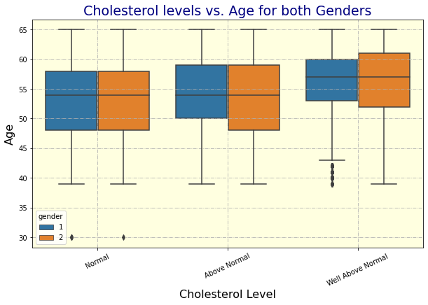

```python
figure, ax1 = plt.subplots(1)
figure.set_size_inches(10,6)

sns.boxplot(x = cardio2.cholesterol, y = cardio2.age, hue = cardio2.gender)
ax1.grid(ls = '-.')
ax1.set_xlabel('Cholesterol Level', size = 16)
ax1.set_ylabel('Age', size = 16)
plt.xticks(np.arange(3), ['Normal', 'Above Normal', 'Well Above Normal'], rotation = 25)
ax1.set_title('Cholesterol levels vs. Age for both Genders', size=19, color='Navy')
ax1.patch.set_facecolor('lightyellow');
```

We see that cholesterol problems appear earlier for males, but we also test that median values are the same for each subgroup of cholesterol levels for both genders. Well Above Normal values tend to appear as people get older.

### e) Glucose level as a factor for CVD

Now it is time to prove the relations between `cardio` target and glucose level in blood.

We can prove that most of the people have normal glucose levels on blood, and only few people have it above normal levels.

[figure not shown]

```python
figure, ax1 = plt.subplots(1)
figure.set_size_inches(10,6)

sns.countplot(cardio2.gluc)
ax1.grid(ls = '-.')
ax1.set_xlabel('Glucose Level', size = 16)
ax1.set_ylabel('Number of cases', size = 16)
plt.xticks(np.arange(3), ['Normal', 'Above Normal', 'Well Above Normal'], rotation = 25)
ax1.set_title('Glucose levels vs. Age for both Genders', size=19, color='Navy')
ax1.patch.set_facecolor('lightyellow');
```

If we study glucose levels grouped by `cardio` target, we will check that higher the glucose-in-blood level, the higher chances to develop a CVD.

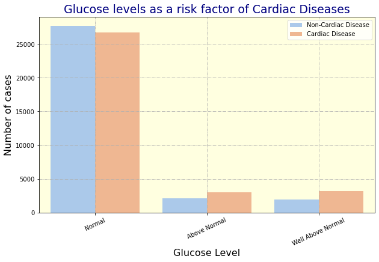

```python
figure, ax1 = plt.subplots(1)
figure.set_size_inches(10,6)

sns.countplot(ax = ax1, x=cardio2.gluc, hue=cardio2.cardio, palette='pastel')
ax1.grid(ls = '-.')
ax1.set_xlabel('Glucose Level', size = 16)
ax1.set_ylabel('Number of cases', size = 16)
plt.xticks(np.arange(3), ['Normal', 'Above Normal', 'Well Above Normal'], rotation = 25)
ax1.legend(['Non-Cardiac Disease', 'Cardiac Disease'])
ax1.set_title('Glucose levels as a risk factor of Cardiac Diseases', size=19, color='Navy')
ax1.patch.set_facecolor('lightyellow');
```

#### Glucose levels vs Ages vs Gender

If we represent a boxplot for `gluc` levels for different ages and grouped bygender, we see that values are distributed in the same way for each gender; maybe above normal values appear previously on males, but that diffence at first quantile is not really significant.

Higher glucose levels tend to appear as people become elder.

[figure not shown]

```python
figure, ax1 = plt.subplots(1)
figure.set_size_inches(10,6)

sns.boxplot(x = cardio2.gluc, y = cardio2.age, hue = cardio2.gender)
ax1.grid(ls = '-.')
ax1.set_xlabel('Cholesterol Level', size = 16)
ax1.set_ylabel('Age', size = 16)
plt.xticks(np.arange(3), ['Normal', 'Above Normal', 'Well Above Normal'], rotation = 25)
ax1.set_title('Cholesterol levels vs. Age for both Genders', size=19, color='Navy')
ax1.patch.set_facecolor('lightyellow');
```

### f) Blood Pressure as a factor for CVD

Once I have created the `BP` variable, we can study the behaviour of blood pressure in a more intuitive way.

Plotting the histogram for the BP distribution, we check that most of people in the dataset have normal blood pressure, but there are also so many cases of Elevated and High Pressure 1.

[figure not shown]

```python
figure, ax1 = plt.subplots(1)
figure.set_size_inches(10,6)
sns.countplot(cardio2.BP)
plt.xticks(rotation = 25)
ax1.grid(ls = '-.')
ax1.set_xlabel('Glucose Level', size = 16)
ax1.set_ylabel('Number of cases', size = 16)
ax1.set_title('Glucose levels as a risk factor of Cardiac Diseases', size=19, color='Navy')
ax1.patch.set_facecolor('lightyellow');
```

Checking now the behaviour of `BP` versus the `cardio` target variable, we will notice that having above-normal blood pressure values increment undoubtely the chances of developing CV problems. On the other hand, the more normal or lower BP you have, the less chances of getting CV diseases you have.

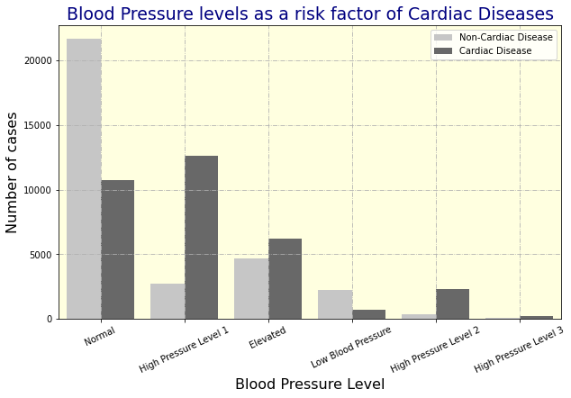

```python
figure, ax1 = plt.subplots(1)
figure.set_size_inches(10,6)

sns.countplot(ax = ax1, x=cardio2.BP, hue=cardio2.cardio, palette='Greys')
ax1.grid(ls = '-.')
ax1.set_xlabel('Blood Pressure Level', size = 16)
ax1.set_ylabel('Number of cases', size = 16)
plt.xticks(rotation = 25)
ax1.legend(['Non-Cardiac Disease', 'Cardiac Disease'])
ax1.set_title('Blood Pressure levels as a risk factor of Cardiac Diseases', size=19, color='Navy')
ax1.patch.set_facecolor('lightyellow');
```

#### BP vs Age and gender

[figure not shown]

```python
figure, ax1 = plt.subplots(1)
figure.set_size_inches(10,6)

sns.boxplot(cardio2.BP, cardio2.age, hue = cardio2.gender)

plt.xticks(rotation = 25)
ax1.grid(ls = '-.')
ax1.set_xlabel('Glucose Level', size = 16)
ax1.set_ylabel('Age', size = 16)
ax1.set_title('Blood Pressure levels vs Age for both gender', size=19, color='Navy')
ax1.patch.set_facecolor('lightyellow');
```

In that boxplot, we see that above normal values follow the same trend: BP problems appear a bit earlier for males (we see it at the first quartile), but they seem to have the same median value for both gender (except elevated one, whose median is slightly lower for males, indicating that men develop elevated BP problems earlier than women).

### g) Activity, Smoking and Alcoholism as a factor for CVD

I will represent all of this crosstabs at the same time because, as we will see, they don't have really a significant meaning on developing a CVD:

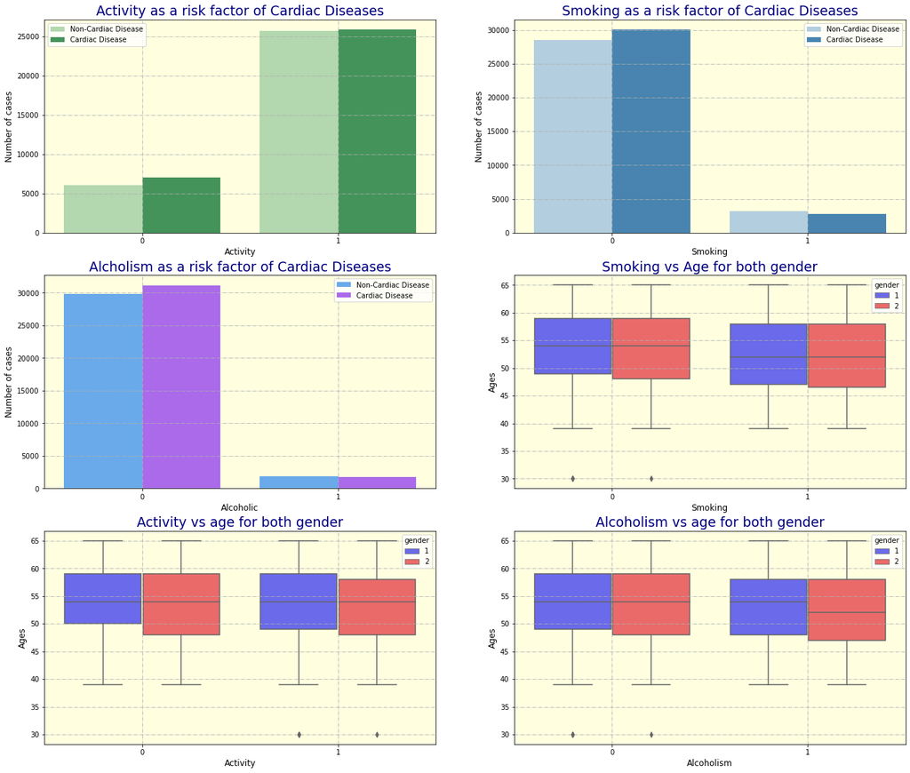

```python
figure, ax1 = plt.subplots(3,2)
figure.set_size_inches(22,19)

sns.countplot(ax = ax1[0,0], x=cardio2.active, hue=cardio2.cardio, palette='Greens')
ax1[0,0].grid(ls = '-.')
ax1[0,0].legend(['Non-Cardiac Disease', 'Cardiac Disease'])
ax1[0,0].set_title('Activity as a risk factor of Cardiac Diseases', size=19, color='Navy')
ax1[0,0].set_xlabel('Activity', size = 12)
ax1[0,0].set_ylabel('Number of cases', size = 12)
ax1[0,0].patch.set_facecolor('lightyellow');

sns.countplot(ax = ax1[0,1], x=cardio2.smoke, hue=cardio2.cardio, palette = 'Blues')
ax1[0,1].grid(ls = '-.')
ax1[0,1].legend(['Non-Cardiac Disease', 'Cardiac Disease'])
ax1[0,1].set_title('Smoking as a risk factor of Cardiac Diseases', size=19, color='Navy')
ax1[0,1].set_xlabel('Smoking', size = 12)
ax1[0,1].set_ylabel('Number of cases', size = 12)
ax1[0,1].patch.set_facecolor('lightyellow');

sns.countplot(ax = ax1[1,0], x=cardio2.alco, hue=cardio2.cardio, palette = 'cool')
ax1[1,0].grid(ls = '-.')
ax1[1,0].legend(['Non-Cardiac Disease', 'Cardiac Disease'])
ax1[1,0].set_title('Alcholism as a risk factor of Cardiac Diseases', size=19, color='Navy')
ax1[1,0].set_xlabel('Alcoholic', size = 12)
ax1[1,0].set_ylabel('Number of cases', size = 12)
ax1[1,0].patch.set_facecolor('lightyellow');

sns.boxplot(ax = ax1[1,1], x=cardio2.smoke, y = cardio2.age, hue=cardio2.gender, palette='seismic')
ax1[1,1].grid(ls = '-.')
ax1[1,1].set_title('Smoking vs Age for both gender', size=19, color='Navy')
ax1[1,1].set_xlabel('Smoking', size = 12)
ax1[1,1].set_ylabel('Ages', size = 12)
ax1[1,1].patch.set_facecolor('lightyellow');

sns.boxplot(ax = ax1[2,0], x=cardio2.active, y = cardio2.age, hue=cardio2.gender, palette='seismic')
ax1[2,0].grid(ls = '-.')
ax1[2,0].set_title('Activity vs age for both gender', size=19, color='Navy')
ax1[2,0].set_xlabel('Activity', size = 12)
ax1[2,0].set_ylabel('Ages', size = 12)
ax1[2,0].patch.set_facecolor('lightyellow');

sns.boxplot(ax = ax1[2,1], x=cardio2.alco, y = cardio2.age, hue=cardio2.gender, palette='seismic')
ax1[2,1].grid(ls = '-.')
ax1[2,1].set_title('Alcoholism vs age for both gender', size=19, color='Navy')
ax1[2,1].set_xlabel('Alcoholism', size = 12)
ax1[2,1].set_ylabel('Ages', size = 12)
ax1[2,1].patch.set_facecolor('lightyellow');
```

We can see in that plots that there is not much information to get; this may be because there are only two possible values for each variables: 0 or 1. We don't know what criterion people have followed to complete this values: what do they consider for smoking, or what do they consider to be alcoholic or active, etc. If there were more than two values to choose (I mean, for example: 0-0.33: Non alcoholic, 0.33-0.66: Occasionally alcoholic consumer, 0.66-1: habitual alcoholic, it will be better, because we would be able to relate better those variables and target `cardio`).

Anyway, we can also see that activity lead to reduce chances of CV disease (as we expected).

### h) Other relations between data

If we represent glucose levels for each IMC group, we see that above normal glucose levels are predominetly above normal IMC-values people.

At the same time, we see that higher cholesterol levels are dominated by over-normal IMC values.

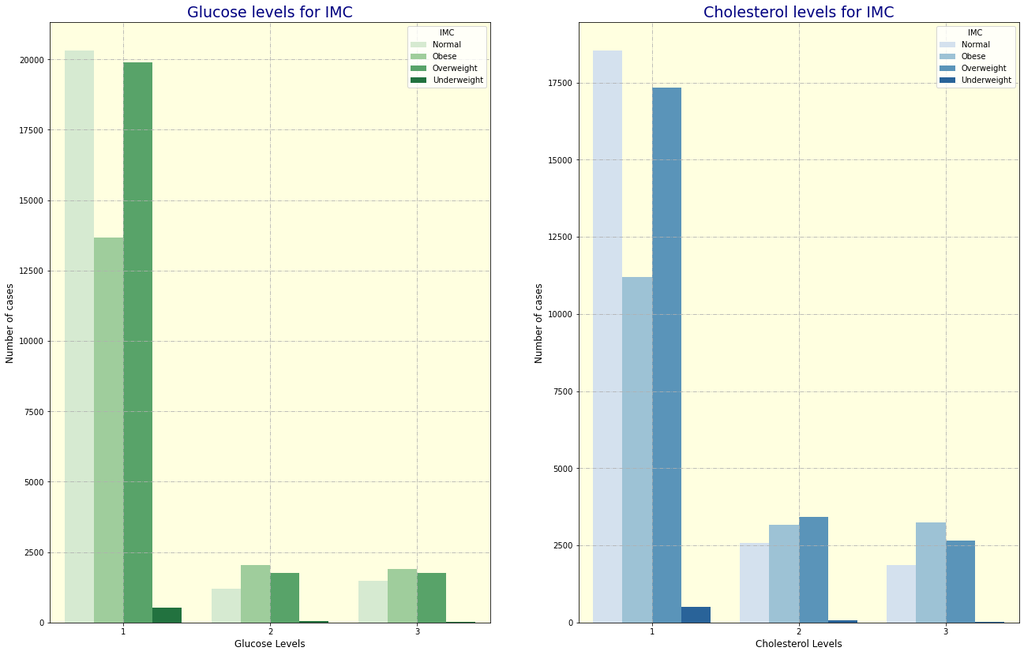

```python
figure, ax1 = plt.subplots(1,2)
figure.set_size_inches(22,14)

sns.countplot(ax = ax1[0], x=cardio2.gluc, hue=cardio2.IMC, palette='Greens')
ax1[0].grid(ls = '-.')
ax1[0].set_title('Glucose levels for IMC', size=19, color='Navy')
ax1[0].set_xlabel('Glucose Levels', size = 12)
ax1[0].set_ylabel('Number of cases', size = 12)
ax1[0].patch.set_facecolor('lightyellow');

sns.countplot(ax = ax1[1], x=cardio2.cholesterol, hue=cardio2.IMC, palette = 'Blues')
ax1[1].grid(ls = '-.')
ax1[1].set_title('Cholesterol levels for IMC', size=19, color='Navy')
ax1[1].set_xlabel('Cholesterol Levels', size = 12)
ax1[1].set_ylabel('Number of cases', size = 12)
ax1[1].patch.set_facecolor('lightyellow');
```

## Correlations between data

If we perform a correlation plot between variables, once we have corrected and improved the dataframe, we will be able to see how related they are between each other.

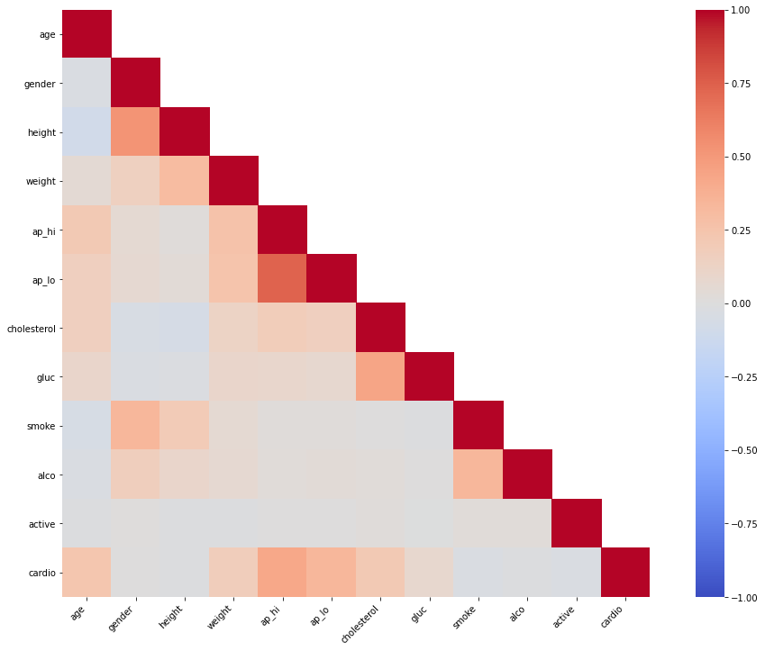

```python
ax, figure = plt.subplots(1, figsize = (18,12))

corr = cardio2.corr()

#triu numpy's command return the upper triangular matrix of a matrix given. I put +1 because I want to show the main diagonal
#values of correlation matrix on the plot.

mask = np.triu(np.ones_like(corr, dtype=bool), +1)



ax = sns.heatmap(
    corr,
    vmin=-1, vmax=1, center=0,
    cmap= 'coolwarm',
    square=True,
    mask = mask
)
ax.set_xticklabels(
    ax.get_xticklabels(),
#     ax.xticks(np.arange(12), ('Age','Gender', 'Height', 'Weight'), rotation = 45)
    rotation=45,
    horizontalalignment='right'
);
```

We can see that target variable `cardio` is positively correlated to `ap_hi`, `ap_lo`, `cholesterol`, `gluc`, `age` and `weight`, as we have seen in the plots that I have made before.

We can also check again that `smoke` and `alco` don't seem to have relations whith `cardio`.

One important thing is that `active` and `cardio` have negative correlation (slightly but present): this is because the more active you are, the less chances of getting CVD you have.

Other important relations appear between: `ap_lo` and `ap_hi`(obviously), `cholesterol` and `gluc`, `height` and `gender` and `smoke` and `alco`.

Representing the correlation matrix with its values:

```python
corr = cardio2.corr()
corr.style.background_gradient(cmap='BuGn')
```

|  | age | gender | height | weight | ap_hi | ap_lo | cholesterol | gluc | smoke | alco | active | cardio |
| --- | --- | --- | --- | --- | --- | --- | --- | --- | --- | --- | --- | --- |
| age | 1.000000 | -0.024224 | -0.089772 | 0.054002 | 0.211028 | 0.156645 | 0.157148 | 0.099404 | -0.050283 | -0.030567 | -0.010085 | 0.235443 |
| gender | -0.024224 | 1.000000 | 0.531006 | 0.150152 | 0.056772 | 0.064855 | -0.045611 | -0.027514 | 0.341410 | 0.171474 | 0.009280 | 0.000464 |
| height | -0.089772 | 0.531006 | 1.000000 | 0.310947 | 0.018525 | 0.035051 | -0.056935 | -0.021206 | 0.199670 | 0.099754 | -0.009741 | -0.011507 |
| weight | 0.054002 | 0.150152 | 0.310947 | 1.000000 | 0.264032 | 0.251555 | 0.131624 | 0.100498 | 0.060197 | 0.062643 | -0.011483 | 0.172581 |
| ap_hi | 0.211028 | 0.056772 | 0.018525 | 0.264032 | 1.000000 | 0.734728 | 0.187160 | 0.087990 | 0.021673 | 0.030810 | 0.004499 | 0.426968 |
| ap_lo | 0.156645 | 0.064855 | 0.035051 | 0.251555 | 0.734728 | 1.000000 | 0.158949 | 0.072803 | 0.022248 | 0.034892 | 0.002105 | 0.342190 |
| cholesterol | 0.157148 | -0.045611 | -0.056935 | 0.131624 | 0.187160 | 0.158949 | 1.000000 | 0.442268 | 0.002020 | 0.029012 | 0.018394 | 0.213159 |
| gluc | 0.099404 | -0.027514 | -0.021206 | 0.100498 | 0.087990 | 0.072803 | 0.442268 | 1.000000 | -0.011910 | 0.005439 | -0.000429 | 0.080452 |
| smoke | -0.050283 | 0.341410 | 0.199670 | 0.060197 | 0.021673 | 0.022248 | 0.002020 | -0.011910 | 1.000000 | 0.338279 | 0.029837 | -0.024594 |
| alco | -0.030567 | 0.171474 | 0.099754 | 0.062643 | 0.030810 | 0.034892 | 0.029012 | 0.005439 | 0.338279 | 1.000000 | 0.028767 | -0.015447 |
| active | -0.010085 | 0.009280 | -0.009741 | -0.011483 | 0.004499 | 0.002105 | 0.018394 | -0.000429 | 0.029837 | 0.028767 | 1.000000 | -0.029333 |
| cardio | 0.235443 | 0.000464 | -0.011507 | 0.172581 | 0.426968 | 0.342190 | 0.213159 | 0.080452 | -0.024594 | -0.015447 | -0.029333 | 1.000000 |

## Conclusion

Once I have performed the EDA for this dataset of CV diseases, there are some conclusions that seem important:

- `Age` is a risk factor for developing a CVD.
- `IMC` is a very high risk factor for CVD as it becomes higher.
- `cholesterol` is a very high risk factor in the development of CV problems.
- `BP` tends to contribute to get CV problems.
- `gluc` level seems to be an important factor in CVD development.

On the other hand:

- `smoke` and `alco` in the way they are presented are not usefull for this study.
- `active` values are a little bit usefull, but they should be redimensioned in order to return better results to our study.

## Bibliography

https://www.kaggle.com/sulianova/cardiovascular-disease-dataset

https://www.kaggle.com/ekami66/detailed-exploratory-data-analysis-with-python

https://towardsdatascience.com/exploratory-data-analysis-tutorial-in-python-15602b417445

https://www.kaggle.com/sulianova/eda-cardiovascular-data